# Homework 3

Sangeeta Mondal

2/27/2018

```r
library(ggplot2)
library(dplyr)
library(readr)
library(shiny)
library(DBI)
library(RSQLite)
library(sqldf)
```

## Q1 LA City Employee Payroll

### 1. For efficiency of the Shiny app, you should first pre-process, pare down, tidy, and save the data, e.g., as a compressed RDS file, to be used in the app.

```r
#setwd("~/biostat-m280-2018-winter/hw3/question1")

payroll <- read_csv(file = '/home/m280-data/la_payroll/LA_City_Employee_Payroll.csv',
                    col_names = TRUE)


payroll_p <- payroll %>% select(Year, `Row ID`, `Department Title`,
                                `Job Class Title`,
                                `Projected Annual Salary`, `Total Payments`,
                                `Base Pay`, `Overtime Pay`,
                                `Other Pay (Payroll Explorer)`)
names(payroll_p) <- c('Year', 'Row ID', 'Department_Title', 'Job_Class_Title' ,
                      'Proj_An_Sal', 'Total_Pay', 'Base_Pay',
                      'Overtime_Pay', 'Other_Pay')

payroll_p <- payroll_p %>% mutate('Total Pay ($)' =
                                   round(as.numeric(gsub('\\$|,', '',
                                                         Total_Pay)),2),
                                 'Base Pay ($)' =
                                   round(as.numeric(gsub('\\$|,', '',
                                                         Base_Pay)),2),
                                 'Overtime Pay ($)' =
                                   round(as.numeric(gsub('\\$|,', '',
                                                         Overtime_Pay)),2),
                                 'Other Pay ($)' =
                                   round(as.numeric(gsub('\\$|,', '',
                                                         Other_Pay)),2))
saveRDS(payroll_p, '/home/mondals/biostat-m280-2018-winter/hw3/question1/payroll_p.rds',
        compress = TRUE)

#If you want to run RDS file locally, then save payroll_p.rds in to your desired
#wd. My desired wd is written in the comment at the beginning of this code block.
#Please do not points off for reproducibility!!!!! :):)

# I have other 'processed' datasets in the app.R file as well that I used to build my Shiny App. They
# are all described in the app.R file with relation to every question! I just kept them in the app.R
# because they are more inherently tied to the app than the RDS file.
```

For the rest of the question, please refer to app.R!

## Q2 LA City Parking War

### 1. How many tickets are in this data set? Which time period do these tickets span? Which years have most data?

How many tickets are in this data set?

```r
#connect to SQLite DB
con <- dbConnect(RSQLite:: SQLite(),
                 '/home/m280-data/la_parking/LA_Parking_Citations.sqlite')
dbListTables(con)
```

```
## [1] "latix"
```

```r
tick <- dplyr::tbl(con, "latix")
```

NOTE: I just kept a description of all the variables in the document using the below SQLite command.

```r
res <- dbSendQuery(con, 'pragma table_info(latix)')
dbFetch(res)
dbClearResult(res)
```

[output not shown]

```r
numtick<- tick %>%
  select(Ticket_number) %>%
  summarize(num_t = n_distinct(Ticket_number)) %>%
  collect()

numtick
```

```
## # A tibble: 1 x 1
##     num_t
##     <int>
## 1 4044338
```

Which time periods to these tickets span?

```r
timep <- tick %>%
  select(Issue_DateTime) %>%
  summarize( min = min(Issue_DateTime, na.rm = TRUE),
             max = max(Issue_DateTime, na.rm = TRUE)) %>%

  collect()

min <- sqldf('Select datetime(min,"unixepoch","localtime") from timep')
max <- sqldf('Select datetime(max, "unixepoch", "localtime") from timep')

min
```

```
##   datetime(min,"unixepoch","localtime")
## 1                   2010-04-27 14:40:00
```

```r
max
```

```
##   datetime(max, "unixepoch", "localtime")
## 1                     2017-12-29 17:41:00
```

Refer to the output above to see the specific datetime ranges. The earliest time was 04-27-2010 14:40. The latest time was 12-29-2017 17:41.

Which years have most data?

```r
years <- dbSendQuery(con,
    'Select (strftime("%Y", datetime(Issue_DateTime, "unixepoch", "localtime")))
    as Year,
                    count(*) from latix
                    GROUP BY Year
                    ORDER BY count(*) DESC')
dbFetch(years)
```

```
##   Year count(*)
## 1 2015  2161172
## 2 2016  1763100
## 3 <NA>    51084
## 4 2014    39326
## 5 2017    29719
## 6 2013       38
## 7 2012       29
## 8 2010       10
## 9 2011       10
```

```r
dbClearResult(years)
```

2015 and 2016 have the most data.

### 2. When (which hour, weekday, month day, and month) are you most likely to get a ticket and when are you least likely to get a ticket?

```r
#hour
hour <- dbSendQuery(con,
    'Select (strftime("%H", datetime(Issue_DateTime, "unixepoch", "localtime")))
      as Hour,
                        count(*) from latix
                        GROUP BY Hour
                        ORDER BY count(*) DESC')
dbFetch(hour)
```

```
##    Hour count(*)
## 1    03   443462
## 2    05   431919
## 3    01   424479
## 4    04   386649
## 5    02   315177
## 6    06   233759
## 7    09   207900
## 8    00   203727
## 9    07   178181
## 10   11   173172
## 11   08   169757
## 12   10   164969
## 13   12   126908
## 14   18    82401
## 15   13    70955
## 16   15    66941
## 17   14    63401
## 18   23    56623
## 19 <NA>    51084
## 20   19    49108
## 21   16    33637
## 22   17    31283
## 23   20    28426
## 24   22    25583
## 25   21    24987
```

```r
dbClearResult(hour)
```

```r
#weekday
wkday <- dbSendQuery(con,
    'Select (strftime("%w", datetime(Issue_DateTime, "unixepoch", "localtime")))
    as weekday,
                        count(*) from latix
                        GROUP BY weekday
                        ORDER BY count(*) DESC')
dbFetch(wkday)
```

```
##   weekday count(*)
## 1       2   798619
## 2       4   755039
## 3       3   753919
## 4       1   684007
## 5       5   642766
## 6       0   218830
## 7       6   140224
## 8    <NA>    51084
```

```r
dbClearResult(wkday)
```

Tuesday and Thursday are the most common weekdays to get ticketed.

```r
#monthday
mnthd <- dbSendQuery(con,
    'Select (strftime("%d", datetime(Issue_DateTime, "unixepoch", "localtime")))
    as mnthd,
                        count(*) from latix
                        GROUP BY mnthd
                        ORDER BY count(*) DESC')
dbFetch(mnthd)
```

```
##    mnthd count(*)
## 1     22   143769
## 2     08   141247
## 3     13   140330
## 4     09   139489
## 5     20   138445
## 6     06   137501
## 7     12   136385
## 8     02   135594
## 9     23   135161
## 10    17   133745
## 11    29   133451
## 12    21   132464
## 13    11   131947
## 14    05   131705
```

[output cut: 18 more lines]

```r
dbClearResult(mnthd)
```

The 22nd and the 8th are the most common month days to get ticketed.

```r
#month

mnth <- dbSendQuery(con,
    'Select (strftime("%m", datetime(Issue_DateTime, "unixepoch", "localtime")))
    as mnth,
                        count(*) from latix
                        GROUP BY mnth
                        ORDER BY count(*) DESC')
dbFetch(mnth)
```

```
##    mnth count(*)
## 1    03   391836
## 2    08   386547
## 3    06   381148
## 4    05   368468
## 5    01   360759
## 6    07   357059
## 7    09   352228
## 8    04   348537
## 9    02   348464
## 10   10   315842
## 11   12   205441
## 12   11   177075
## 13 <NA>    51084
```

```r
dbClearResult(mnth)
```

The most common months to get ticketed are March and August.

### 3. Which car makes received most citations?

```r
m_cit <- tick %>%
  select(Ticket_number, Make)%>%
  group_by(Make)%>%
  summarize(Most_Citations = n())%>%
  arrange(desc(Most_Citations))%>%
  collect()

m_cit
```

```
## # A tibble: 1,086 x 2
##    Make  Most_Citations
##    <chr>          <int>
##  1 TOYT          669548
##  2 HOND          450020
##  3 FORD          362072
##  4 NISS          277215
##  5 CHEV          276530
##  6 BMW           184837
##  7 MERZ          163487
##  8 VOLK          145522
##  9 DODG          116883
## 10 HYUN          116744
## # ... with 1,076 more rows
```

Toyota and Honda received the most citations (but this might also be that higher proportions of people own Toyota and Honda!).

### 4. How many different colors of cars were ticketed? Which color attracted most tickets?

```r
color_cit <- tick %>%
  select(Ticket_number, Color) %>%
  group_by(Color) %>%
  summarize(Most_Citations = n()) %>%
  arrange(desc(Most_Citations))%>%
  collect()

color_cit
```

```
## # A tibble: 66 x 2
##    Color Most_Citations
##    <chr>          <int>
##  1 BK            862283
##  2 WT            818655
##  3 GY            765598
##  4 SL            516384
##  5 BL            317921
##  6 RD            205304
##  7 GN            129521
##  8 BN             86879
##  9 GO             59337
## 10 MR             50064
## # ... with 56 more rows
```

There 66 different colors of cars ticketed. Black and white colored cars attracted the most tickets (though as above, this might also be because higher proportions of people own black and white cars).

### 5. What are the most common ticket types?

```r
viol_code <- tick %>%
  select(Ticket_number, Violation_code) %>%
  group_by(Violation_code) %>%
  summarize(Most = n()) %>%
  arrange(desc(Most)) %>%
  collect()

viol_code
```

```
## # A tibble: 264 x 2
##    Violation_code    Most
##    <chr>            <int>
##  1 80.69BS        1088868
##  2 88.13B+         773228
##  3 80.58L          281060
##  4 80.56E4+        257830
##  5 5204A-          243638
##  6 80.69B          173260
##  7 80.69C          142141
##  8 5200            106305
##  9 80.56E1          98994
## 10 80.69AP+         73794
## # ... with 254 more rows
```

```r
viol_des <- tick %>%
  select(Ticket_number, Violation_Description)%>%
  group_by(Violation_Description)%>%
  summarize(Most = n())%>%
  arrange(desc(Most))%>%
  collect()

viol_des
```

```
## # A tibble: 500 x 2
##    Violation_Description    Most
##    <chr>                   <int>
##  1 NO PARK/STREET CLEAN  1149021
##  2 METER EXP.             773228
##  3 PREFERENTIAL PARKING   281060
##  4 RED ZONE               274880
##  5 DISPLAY OF TABS        243638
##  6 NO PARKING             182747
##  7 PARKED OVER TIME LIM   142055
##  8 DISPLAY OF PLATES      106305
##  9 WHITE ZONE             102387
## 10 NO STOP/STANDING        73794
## # ... with 490 more rows
```

The most common violation code is 80.69BS. The mot common violation description is NO PARK/STREET Clean.

### 6. How much money was collected on parking tickets in 2015 and 2016?

```r
mon_p <- tick %>%
  select(Ticket_number, Issue_DateTime, Fine_amount)%>%
  collect() %>%
  mutate(Convert = as.POSIXct(Issue_DateTime, origin = "1970-01-01", tz = 'PST'),
         Year = format(Convert, '%Y')) %>%
  group_by(Year) %>%
  summarize(Fine_Sum = sum(Fine_amount, na.rm = TRUE)) %>%
  filter(Year %in% c(2015, 2016)) %>%
  collect()

mon_p
```

```
## # A tibble: 2 x 2
##   Year   Fine_Sum
##   <chr>     <int>
## 1 2015  151006794
## 2 2016  123236136
```

In 2015, 151,006,794 dollars was collected on parking tickets. In 2016, 123,236,136 dollars was collected. LA County is going to get rich off of parking citations!!!!!

### 7. Visualize any other information you are interested in.

Do the number of citations change if we look at it by color of car and make?

I made a table. Furthermore, I made a bar graph to observe the number of citations per car color.

```r
cmak <- tick %>%
  select(Ticket_number, Color, Make)%>%
  group_by(Color, Make)%>%
  summarize(cits = n()) %>%
  arrange(desc(cits))%>%
  collect()

cmak
```

```
## # A tibble: 4,207 x 3
## # Groups:   Color [66]
##    Color Make    cits
##    <chr> <chr>  <int>
##  1 GY    TOYT  148969
##  2 WT    TOYT  129985
##  3 BK    TOYT  110406
##  4 SL    TOYT  110211
##  5 WT    FORD  103330
##  6 GY    HOND  103052
##  7 BK    HOND   93042
##  8 WT    CHEV   72635
##  9 SL    HOND   72394
## 10 BK    FORD   65076
## # ... with 4,197 more rows
```

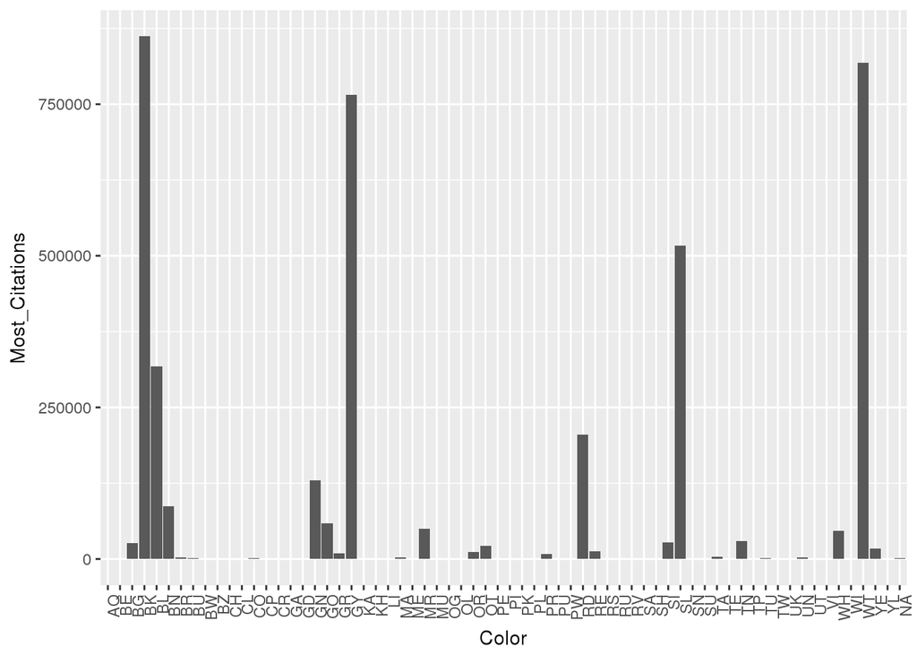

```r
ggplot (data = color_cit) +
  geom_bar (mapping = aes(x = Color, y= Most_Citations), stat = 'identity') +
  theme(axis.text.x = element_text(angle = 90, hjust = 1))
```